# M2_883_RL_PEC2_Solucion

[figure not shown]

M2.883 · Aprendizaje por refuerzo

Máster universitario en Ciencia de datos (*Data science*)

Estudios de Informática, Multimedia y Telecomunicación

# PEC2: Deep Reinforcement Learning

1. DQN
2. Double DQN (DDQN)
3. REINFORCE con línea de base
4. REINFORCE con reward modificado

Finalmente, crearemos un entorno de cero y lo resolveremos.

**Importante: La entrega debe hacerse en formato notebook y en formato html donde se vea el código y los resultados y comentarios de cada ejercicio. Para exportar el notebook a html puede hacerse desde el menú File → Download as → HTML.**

## 0. Contexto

**Mountain Car** consiste en un coche situado en un valle. El coche tiene muy poca potencia y sólo con su motor no es capaz de salir del valle porque la gravedad es más fuerte. Para ello, el agente debe conseguir impulsar el coche, ya sea acelerando hacia adelante o hacia atrás a la velocidad más adecuada para poder llegar a la cima de la montaña y salir del valle.

Las acciones que puede realizar el coche son las siguientes:

- 0 : Acelerar hacia a la izquierda
- 1 : No usar el motor
- 2 : Acelerar hacia la derecha

[figure not shown]

El agente recibirá una recompensa (penalización) de -1 cada vez que no consiga llegar a la posición objetivo.

Para más detalles sobre la definición del entorno de MountainCar, se recomienda consultar el código fuente: https://github.com/openai/gym/blob/master/gym/envs/classic_control/mountain_car.py

Cada episodio termina cuando el coche ha llegado al punto objetivo o si se han realizado 200 pasos. La solución óptima es aquella en la que el agente, con un desplazamiento eficiente, consigue llegar a la cima en el menor número de pasos posible.

## 1. Inicialización y exploración del entorno (0.5 ptos)

Empezaremos cargando las principales librerías necesarias para la práctica:

```python
import gym
import matplotlib.pyplot as plt
%matplotlib inline
import torch
import numpy as np
import time
```

**Ejercicio (0.1 ptos):** Inicializar el entorno 'MountainCar-v0'. Extraer:

- Valor del umbral de recompensa definido en el entorno
- Máximo de pasos establecidos por cada episodio
- Dimensión del espacio de acciones
- Espacio de estados
- Dimensión del espacio de estados
- Valores mínimos permitidos de posición y velocidad
- Valores máximos permitidos de posición y velocidad

```python
##TODO:
env = gym.make('MountainCar-v0')
```

```python
##TODO:
print('Reward threshold: ' + str(env.spec.reward_threshold))
print('Maximum episodes steps: ' + str(env.spec.max_episode_steps))
print('Action space dimension: ' + str(env.action_space))
print('State space: ' + str(env.observation_space)) ####
print('Space dimension: ' + str(env.observation_space.shape[0]))
print("Highest value position and velocity:",env.observation_space.high) # i.e. (position = 0.6, velocity = 0.07)
print("Lowest value position and velocity:",env.observation_space.low) #(position = -1.2, velocity = -0.07)
```

```
Reward threshold: -110.0
Maximum episodes steps: 200
Action space dimension: Discrete(3)
State space: Box([-1.2  -0.07], [0.6  0.07], (2,), float32)
Space dimension: 2
Highest value position and velocity: [0.6  0.07]
Lowest value position and velocity: [-1.2  -0.07]
```

**Ejercicio (0.2 ptos):** Mostrar la representación vectorial de cada observación del entorno junto con la acción aleatoria seleccionada (ej. 'Observation: [..] , Action: Accelerate left'), en un intervalo de 10 episodios de 100 pasos cada uno. *Opcional*: visualizar los 10 episodios `env.render()`, sólo posible en local

```python
actionsdict = {
    0: "Accelerate left",
    1: "Don't move",
    2: "Accelerate right"
}
```

```python
##TODO:
#Visualizar el entorno
for i_episode in range(10):
    observation = env.reset()
    for t in range(10):
       # env.render()
        action = env.action_space.sample() #acción aleatoria
        print("Observation: " + str(observation))
        print("Action: " + str(actionsdict[action]))
        observation, reward, done, info = env.step(action) #ejecución de la acción elegida
        print("Reward: " + str(reward) + "\n\n")
        if done:
            print("Episode finished after {} timesteps".format(t+1))
            break
env.close() #cerramos la visualización del entorno
```

```
Observation: [-0.5049497  0.       ]
Action: Accelerate left
Reward: -1.0


Observation: [-0.5060895 -0.0011398]
Action: Don't move
Reward: -1.0


Observation: [-0.5073606  -0.00127105]
Action: Don't move
Reward: -1.0


Observation: [-0.50875336 -0.00139279]
Action: Accelerate right
Reward: -1.0


Observation: [-5.0925744e-01 -5.0409662e-04]
Action: Accelerate right
Reward: -1.0


Observation: [-5.0886905e-01  3.8837659e-04]
Action: Accelerate left
Reward: -1.0


Observation: [-0.5095911  -0.00072206]
Action: Accelerate left
Reward: -1.0


Observation: [-0.5114182  -0.00182709]
Action: Accelerate right
Reward: -1.0


```

[output cut: 443 more lines]

```


Observation: [-0.4968667   0.00303978]
Action: Accelerate right
Reward: -1.0


Observation: [-0.4930272  0.0038395]
Action: Don't move
Reward: -1.0


Observation: [-0.48941666  0.00361054]
Action: Don't move
Reward: -1.0
```

**Ejercicio (0.2 ptos):** Ejecutar 1000 episodios con el máximo de pasos establecido en el entorno de MountainCar, tomando acciones de forma aleatoria. Almacenar la posición final del coche en cada episodio, y mostrar el resultado en un gráfico. Comentar el resultado.

```python
##TODO:
position = []

for i_episode in range(1000):
    observation = env.reset()
    done = 0
    while (not done):
        action = env.action_space.sample() #acción aleatoria
        observation, reward, done, info = env.step(action) #ejecución de la acción elegida
        if done:
            position.append(observation[0])
            break
env.close()
```

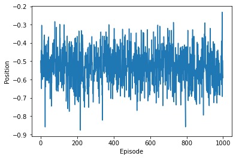

```python
plt.plot(position)
plt.ylabel('Position')
plt.xlabel('Episode')
```

**Solución:**  
Como era de esperar, el coche es incapaz de conseguir el objetivo con simples acciones aleatorias y se queda permanentemente en el valle.

## 2. Agente DQN (2.5 ptos)

En este apartado implementaremos una DQN teniendo en cuenta la exploración-explotación (epsilon-*greedy*), la red objetivo, y el buffer de repetición de experiencias.

Definiremos el buffer como sigue:

```python
from collections import namedtuple, deque
```

```python
class experienceReplayBuffer:

    def __init__(self, memory_size=50000, burn_in=10000):
        self.memory_size = memory_size
        self.burn_in = burn_in
        self.buffer = namedtuple('Buffer',
            field_names=['state', 'action', 'reward', 'done', 'next_state'])
        self.replay_memory = deque(maxlen=memory_size)

    def sample_batch(self, batch_size=32):
        samples = np.random.choice(len(self.replay_memory), batch_size,
                                   replace=False)
        # Use asterisk operator to unpack deque
        batch = zip(*[self.replay_memory[i] for i in samples])
        return batch

    def append(self, state, action, reward, done, next_state):
        self.replay_memory.append(
            self.buffer(state, action, reward, done, next_state))

    def burn_in_capacity(self):
        return len(self.replay_memory) / self.burn_in
```

Primeramente implementaremos la red neuronal, utilizando un modelo Secuencial con la siguiente configuración:

- Tres capas completamente conectadas (representadas en pytorch por `nn.Lineal`) con 512, 256 y 128 neuronas cada una, `bias=True`, y activación ReLU
- Una capa de salida completamente conectada y `bias=True`

Usaremos el optimizador Adam para entrenar la red.

**Ejercicio (0.75 ptos):** Implementar la clase `NeuralNet()`. Inicializar las variables necesarias y definir el modelo Secuencial de red neuronal indicado. ----------------------------------------------------------------------------------------------------------- **Nota**: se os proporciona el código pre-implementado. La implementación que se pide en el enunciado está indicada en los bloques *TODO* y/o con variables igualadas a *None*.

```python
class NeuralNet(torch.nn.Module):

    def __init__(self, env, learning_rate=1e-3):

        """
        Params
        ======
        n_inputs: tamaño del espacio de estados
        n_outputs: tamaño del espacio de acciones
        actions: array de acciones posibles
        """

        ######################################
        ##TODO: Initialize variables
        super(NeuralNet, self).__init__()
        self.n_inputs = env.observation_space.shape[0]
        self.n_outputs = env.action_space.n
        self.actions = np.arange(env.action_space.n)
        self.learning_rate = learning_rate


        #######################################
        ##TODO: Neural network
        self.model = torch.nn.Sequential(
            torch.nn.Linear(self.n_inputs, 512, bias=True),
            torch.nn.ReLU(),
            torch.nn.Linear(512, 256, bias=True),
            torch.nn.ReLU(),
            torch.nn.Linear(256, 128, bias=True),
            torch.nn.ReLU(),
            torch.nn.Linear(128, self.n_outputs, bias=True))



        #######################################
        ##TODO: Initialize optimizer
        self.optimizer = torch.optim.Adam(self.parameters(), lr=self.learning_rate)



    ### e-greedy method
    def get_action(self, state, epsilon=0.05):
        if np.random.random() < epsilon:
            action = np.random.choice(self.actions)  # random action
        else:
            qvals = self.get_qvals(state)  # action from computation of Q for this action
            action= torch.max(qvals, dim=-1)[1].item()
        return action


    def get_qvals(self, state):
        if type(state) is tuple:
            state = np.array([np.ravel(s) for s in state])
        state_t = torch.FloatTensor(state)
        return self.model(state_t)
```

A continuación implementaremos una clase que defina el comportamiento del agente DQN teniendo en cuenta:

- La exploración/explotación (decaimiento de epsilon)
- La actualización y sincronización de la red principal y la red objetivo (pérdida)

Consideraremos que el agente ha aprendido a realizar la tarea (i.e. el "juego" termina) cuando obtiene una media de mínimo -110 puntos durante 100 episodios consecutivos.

**Ejercicio (0.75 ptos):** Implementar los siguientes puntos de la clase `DQNAgent()`:

1. Declarar las variables de la clase
2. Inicializar las variables necesarias
3. Implementar la acción a tomar
4. Actualizar la red principal según la frecuencia establecida en los hiperparámetros
5. Calcular la pérdida (ecuación Bellman, etc)
6. Sincronizar la red objetivo según la frecuencia establecida en los hiperparámetros
7. Calcular la media de recompensas de los últimos 100 episodios
8. Comprobar límite de episodios
9. Actualizar epsilon según: $$\textrm{max}(\epsilon · \epsilon_{\textrm{decay}}, 0.01)$$

Además, durante el proceso se deben almacenar (*):

- Las recompensas obtenidas en cada paso del entrenamiento
- Las recompensas medias cada 100 episodios
- La pérdida durante el entrenamiento
- La posición final del coche en cada episodio
- La evolución de epsilon a lo largo del entrenamiento

----------------------------------------------------------------------------------------------------------- **Nota**: se os proporciona el código pre-implementado. La implementación que se pide en el enunciado está indicada en los bloques *TODO* y/o con variables igualadas a *None*, salvo (*) en qué momento almacenar las variables que se indican.

```python
from copy import deepcopy, copy
```

```python
class DQNAgent:

    ######################################
    ##TODO 1: Declarar variables
    def __init__(self, env, main_network, buffer, reward_threshold, epsilon=0.1, eps_decay=0.99, batch_size=32):

        self.env = env
        self.main_network = main_network
        self.target_network = deepcopy(main_network) # red objetivo (copia de la principal)
        self.buffer = buffer
        self.epsilon = epsilon
        self.eps_decay = eps_decay
        self.batch_size = batch_size
        self.nblock = 100 # bloque de los X últimos episodios de los que se calculará la media de recompensas
        self.reward_threshold = reward_threshold # recompensa media a partir de la cual se considera
                                                               # que el agente ha aprendido a jugar
        self.initialize()

    ######################################
    ##TODO 2: Inicializar otras variables necesarias
    def initialize(self):
        self.update_loss = []
        self.training_rewards = []
        self.mean_training_rewards = []
        self.last_position = []
        self.sync_eps = []
        self.total_reward = 0
        self.step_count = 0
        self.state0 = self.env.reset()
        self.epsilon_evolution = []
        self.training_loss = []


    ######################################
    ##TODO 3: Tomar paso siguiente
    def take_step(self, eps, mode='train'):
        if mode == 'explore':
            # acción aleatoria en el burn-in y en la fase de exploración (epsilon)>
            action = self.env.action_space.sample()
        else:
            # acción a partir del valor de Q (elección de la acción con mejor Q)
            action = self.main_network.get_action(self.state0, eps)
            self.step_count += 1

        #TODO: tomar 'step' i obtener nuevo estado y recompensa. Guardar la experiencia en el buffer
        new_state, reward, done, _ = self.env.step(action)
        self.total_reward += reward
        self.buffer.append(self.state0, action, reward, done, new_state) # guardar experiencia en el buffer
        self.state0 = new_state.copy()

        #TODO: resetear entorno 'if done'
        if done:
            if mode == 'train':
                self.last_position.append(self.state0[0]) #guardar última posición coche
            self.state0 = env.reset()
        return done



    ## Entrenamiento
    def train(self, gamma=0.99, max_episodes=50000,
              batch_size=32,
              dnn_update_frequency=4,
              dnn_sync_frequency=2000):

        self.gamma = gamma

        # Rellenamos el buffer con N experiencias aleatorias ()
        print("Filling replay buffer...")
        while self.buffer.burn_in_capacity() < 1:
            self.take_step(self.epsilon, mode='explore')


        episode = 0
        training = True
        print("Training...")
        while training:
            self.state0 = self.env.reset()
            self.total_reward = 0
            gamedone = False
            while gamedone == False:
                # El agente toma una acción
                gamedone = self.take_step(self.epsilon, mode='train')

                #################################################################################
                #####TODO 4:  Actualizar la red principal según la frecuencia establecida #######
                if self.step_count % dnn_update_frequency == 0:
                    self.update()


                ########################################################################################
                ###TODO 6: Sincronizar red principal y red objetivo según la frecuencia establecida#####
                if self.step_count % dnn_sync_frequency == 0:
                    self.target_network.load_state_dict(
                        self.main_network.state_dict())
                    self.sync_eps.append(episode)


                if gamedone:
                    episode += 1

                    ##################################################################
                    ########TODO: Almacenar epsilon, training rewards y pérdida#######
                    self.epsilon_evolution.append(self.epsilon) # guardamos la evolución de epsilon
                    self.training_rewards.append(self.total_reward) # guardamos las recompensas obtenidas
                    self.training_loss.append(np.mean(self.update_loss)) # guardamos la pérdida
                    ####
                    self.update_loss = []


                    #######################################################################################
                    ###TODO 7: calcular la media de recompensa de los últimos X episodios, y almacenar#####
                    mean_rewards = np.mean(
                        self.training_rewards[-self.nblock:])
                    self.mean_training_rewards.append(mean_rewards)
                    ###

                    print("\rEpisode {:d} Mean Rewards {:.2f} Epsilon {:.6f}\t\t".format(
                        episode, mean_rewards, self.epsilon), end="")

                    #######################################################################################
                    ### TODO 8: Comprobar que todavía quedan episodios. Parar el aprendizaje si se llega al límite
                    if episode >= max_episodes:
                        training = False
                        print('\nEpisode limit reached.')
                        break

                    #Termina el juego si la media de recompensas ha llegado al umbral fijado para este juego
                    if mean_rewards >= self.reward_threshold:
                        training = False
                        print('\nEnvironment solved in {} episodes!'.format(
                            episode))
                        break

                    #################################################################################
                    ######TODO 9: Actualizar epsilon según la velocidad de decaimiento fijada########
                    self.epsilon = max(self.epsilon * self.eps_decay, 0.01)



    #####################################
    #####TODO 5: cálculo de la pérdida###
    def calculate_loss(self, batch):
        # Separamos las variables de la experiencia y las convertimos a tensores
        states, actions, rewards, dones, next_states = [i for i in batch]
        rewards_vals = torch.FloatTensor(rewards)
        actions_vals = torch.LongTensor(np.array(actions)).reshape(-1,1)
        dones_t = torch.ByteTensor(dones)

        # Obtenemos los valores de Q de la red principal
        qvals = torch.gather(self.main_network.get_qvals(states), 1, actions_vals)
        # Obtenemos los valores de Q objetivo. El parámetro detach() evita que estos valores actualicen la red objetivo
        qvals_next = torch.max(self.target_network.get_qvals(next_states),
                               dim=-1)[0].detach()
        qvals_next[dones_t] = 0 # 0 en estados terminales

        #################################################################################
        ### TODO: Calcular ecuación de Bellman
        expected_qvals = self.gamma * qvals_next + rewards_vals

        #################################################################################
        ### TODO: Calcular la pérdida (MSE)
        loss = torch.nn.MSELoss()(qvals, expected_qvals.reshape(-1,1))
        return loss


    def update(self):
        self.main_network.optimizer.zero_grad()  # eliminamos cualquier gradiente pasado
        batch = self.buffer.sample_batch(batch_size=self.batch_size) # seleccionamos un conjunto del buffer
        loss = self.calculate_loss(batch) # calculamos la pérdida
        loss.backward() # hacemos la diferencia para obtener los gradientes
        self.main_network.optimizer.step() # aplicamos los gradientes a la red neuronal
        # Guardamos los valores de pérdida
        self.update_loss.append(loss.detach().numpy())
```

A continuación entrenaremos el modelo con los siguientes hiperparámetros:

- Velocidad de aprendizaje: 0.001
- Tamaño del batch: 32
- Número de episodios: 5000
- Número de episodios para rellenar el buffer: 1000
- Frecuencia de actualización de la red neuronal: 3
- Frecuencia de sincronización con la red objetivo: 1000
- Capacidad máxima del buffer: 10000
- Factor de descuento: 0.99
- Epsilon: 1, con decaimiento de 0.99

**Ejercicio (0.25 ptos):** Declarar los hiperparámetros, cargar el modelo de red neuronal y entrenar el agente. Guardar el modelo entrenado en formato ".pth".

```python
##TODO:
lr = 0.001          #Velocidad aprendizaje 0.00025
MEMORY_SIZE = 10000   #Máxima capacidad del buffer 10000
MAX_EPISODES = 5000   #Número máximo de episodios (el agente debe aprender antes de llegar a este valor)
EPSILON = 1           #Valor inicial de epsilon
EPSILON_DECAY = .99   #Decaimiento de epsilon 0.009
GAMMA = 0.99          #Valor gamma de la ecuación de Bellman
BATCH_SIZE = 32       #Conjunto a coger del buffer para la red neuronal
BURN_IN = 1000        #Número de experiencias iniciales usadas para rellenar el buffer antes de entrenar
DNN_UPD = 3           #Frecuencia de actualización de la red neuronal
DNN_SYNC = 1000       #Frecuencia de sincronización de pesos entre red neuronal y red objetivo
REWARD_THRESHOLD = env.spec.reward_threshold
```

```python
##TODO:
buffer = experienceReplayBuffer(memory_size=MEMORY_SIZE, burn_in=BURN_IN)
nn = NeuralNet(env, learning_rate=lr)
agentDQN = DQNAgent(env, nn, buffer, REWARD_THRESHOLD, EPSILON, EPSILON_DECAY, BATCH_SIZE)
```

```python
start_time = time.time()

##TODO:
agentDQN.train(gamma=GAMMA, max_episodes=MAX_EPISODES,
              batch_size=BATCH_SIZE, dnn_update_frequency=DNN_UPD, dnn_sync_frequency=DNN_SYNC)

end_time = time.time()
print('Training time: ' + str(round((end_time-start_time)/60,2)) + " minutes")
```

```
Filling replay buffer...
Training...
```

```
Episode 1249 Mean Rewards -109.90 Epsilon 0.010000
Environment solved in 1249 episodes!
Training time: 8.7 minutes
```

```python
##TODO:
nn_filename = "agentDQN_Trained_Model.pth"
torch.save(agentDQN.main_network.state_dict(), nn_filename)
```

**Ejercicio (0.25 ptos):** Representar:

1. Gráfico con las recompensas obtenidas a lo largo del entrenamieno, la evolución de las recompensas medias cada 100 episodios, y el umbral de recompensa establecido por el entorno.
2. Gráfico con la posición final del coche en cada episodio
3. Gráfico con la evolución de la perdida a lo largo del entrenamiento
4. Gráfico con la evolución de epsilon a lo largo del entrenamiento

Comentar los resultados obtenidos.

```python
##TODO:
def plot_rewards(tr_rewards, mean_tr_rewards, th):
    plt.figure(figsize=(8,4))
    plt.plot(tr_rewards, label='Rewards')
    plt.plot(mean_tr_rewards, label='Mean Rewards')
    plt.axhline(th, color='r', label="Reward threshold")
    plt.xlabel('Episodes')
    plt.ylabel('Rewards')
    plt.legend(loc="upper left")
    plt.show()
```

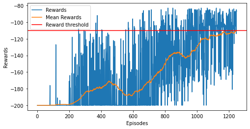

```python
plot_rewards(agentDQN.training_rewards,agentDQN.mean_training_rewards,REWARD_THRESHOLD)
```

```python
def plot_position(positions, th):
    plt.figure(figsize=(8,4))
    plt.plot(positions, label='Last Positions')
    plt.axhline(th, color='r', label="Last Position threshold")
    plt.xlabel('Episodes')
    plt.ylabel('Last Position')
    plt.legend(loc="upper left")
    plt.show()
```

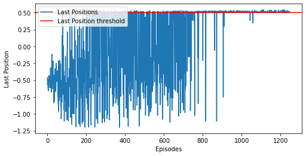

```python
plot_position(agentDQN.last_position, env.goal_position)
```

```python
##TODO:
def plot_loss(tr_loss):
    plt.figure(figsize=(8,4))
    plt.plot(tr_loss, label='Loss')
    plt.xlabel('Episodes')
    plt.ylabel('Loss')
    plt.legend(loc="upper left")
    plt.show()
```

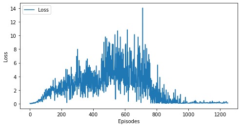

```python
plot_loss(agentDQN.training_loss)
```

```python
##TODO:
def plot_epsilon(eps_evolution):
    plt.figure(figsize=(8,4))
    plt.plot(eps_evolution, label='Epsilon')
    plt.xlabel('Episodes')
    plt.ylabel('Epsilon')
    plt.legend(loc="upper right")
    plt.show()
```

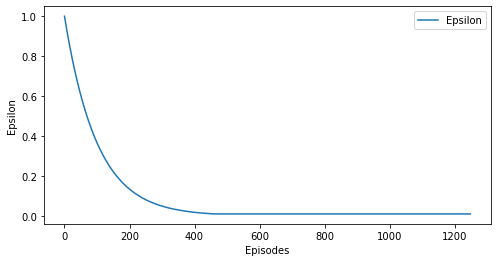

```python
plot_epsilon(agentDQN.epsilon_evolution)
```

**Solución:**  
Aspectos a comentar:

1. Episodios necesarios para resolver el problema
2. Evolución del aprendizaje (continuo, variable, en algún punto deja de mejorar, siempre mejora, posición del coche, etc.)
3. Evolución del decaimiento de epsilon (exploración, explotación). Relación con el momento en qué el agente empieza a aprender?
4. ...

Una vez entrenado el agente, nos interesa comprobar cómo de bien ha aprendido y si es capaz de conseguir que el coche llegue a su objetivo. Para ello, recuperamos el modelo entrenado y dejamos que el agente tome acciones aleatorias según ese modelo y observamos su comportamiento.

**Ejercicio (0.5 ptos):** Cargar el modelo entrenado y ejecutar el agente entrenado durante 100 episodios consecutivos. Almacenar la posición final del agente en cada episodio, y calcular la suma de recompensas por cada episodio. Mostrar:

- un gráfico con la suma de las recompensas respecto de los episodios, incluyendo el umbral de recompensa establecido por el entorno
- un gráfico con la posición final del coche en cada episodio

Comentar los resultados obtenidos. --------------------------------------------------------------------------------------------------- *Opcional*: visualizar los episodios con `env.render()`, sólo posible en local. Esta visualización ralentiza el proceso unos segundos por episodio.

```python
##TODO:
agentDQN.main_network.load_state_dict(torch.load('agentDQN_Trained_Model.pth'))
```

```
<All keys matched successfully>
```

```python
##TODO:
def test_model(ag):
    all_rewards = []
    final_position = []
    for i_episode in range(100):
        observation = env.reset()

        total_reward = 0
    #episode loop
        t=0
        while True:
            #env.render()
            action = ag.main_network.get_action(observation,epsilon=0.0)############
            observation, reward, done, info = env.step(action)
            total_reward += reward
            t=t+1
            if done:
                all_rewards.append(total_reward)
                final_position.append(observation[0])
                break
        print('Episode {}\tAverage Score: {:.2f} \tFinished in {} timesteps \n '.format(i_episode, total_reward, t+1), end="")

    env.close()

    return all_rewards, final_position
```

```python
rewards_test_DQN = test_model(agentDQN)
```

```
Episode 0	Average Score: -108.00 	Finished in 109 timesteps
 Episode 1	Average Score: -105.00 	Finished in 106 timesteps
 Episode 2	Average Score: -106.00 	Finished in 107 timesteps
 Episode 3	Average Score: -114.00 	Finished in 115 timesteps
 Episode 4	Average Score: -105.00 	Finished in 106 timesteps
 Episode 5	Average Score: -91.00 	Finished in 92 timesteps
 Episode 6	Average Score: -105.00 	Finished in 106 timesteps
 Episode 7	Average Score: -89.00 	Finished in 90 timesteps
 Episode 8	Average Score: -153.00 	Finished in 154 timesteps
 Episode 9	Average Score: -106.00 	Finished in 107 timesteps
 Episode 10	Average Score: -155.00 	Finished in 156 timesteps
 Episode 11	Average Score: -89.00 	Finished in 90 timesteps
 Episode 12	Average Score: -150.00 	Finished in 151 timesteps
 Episode 13	Average Score: -104.00 	Finished in 105 timesteps
 Episode 14	Average Score: -91.00 	Finished in 92 timesteps
 Episode 15	Average Score: -104.00 	Finished in 105 timesteps
 Episode 16	Average Score: -90.00 	Finished in 91 timesteps
 Episode 17	Average Score: -153.00 	Finished in 154 timesteps
 Episode 18	Average Score: -105.00 	Finished in 106 timesteps
 Episode 19	Average Score: -106.00 	Finished in 107 timesteps
 Episode 20	Average Score: -95.00 	Finished in 96 timesteps
 Episode 21	Average Score: -98.00 	Finished in 99 timesteps
 Episode 22	Average Score: -103.00 	Finished in 104 timesteps
 Episode 23	Average Score: -85.00 	Finished in 86 timesteps
 Episode 24	Average Score: -122.00 	Finished in 123 timesteps
 Episode 25	Average Score: -104.00 	Finished in 105 timesteps
 Episode 26	Average Score: -108.00 	Finished in 109 timesteps
 Episode 27	Average Score: -87.00 	Finished in 88 timesteps
 Episode 28	Average Score: -91.00 	Finished in 92 timesteps
 Episode 29	Average Score: -106.00 	Finished in 107 timesteps
 Episode 30	Average Score: -114.00 	Finished in 115 timesteps
 Episode 31	Average Score: -86.00 	Finished in 87 timesteps
 Episode 32	Average Score: -106.00 	Finished in 107 timesteps
 Episode 33	Average Score: -93.00 	Finished in 94 timesteps
 Episode 34	Average Score: -151.00 	Finished in 152 timesteps
 Episode 35	Average Score: -97.00 	Finished in 98 timesteps
 Episode 36	Average Score: -93.00 	Finished in 94 timesteps
 Episode 37	Average Score: -108.00 	Finished in 109 timesteps
 Episode 38	Average Score: -84.00 	Finished in 85 timesteps
 Episode 39	Average Score: -105.00 	Finished in 106 timesteps
```

[output cut: 45 more lines]

```
 Episode 85	Average Score: -84.00 	Finished in 85 timesteps
 Episode 86	Average Score: -91.00 	Finished in 92 timesteps
 Episode 87	Average Score: -94.00 	Finished in 95 timesteps
 Episode 88	Average Score: -105.00 	Finished in 106 timesteps
 Episode 89	Average Score: -106.00 	Finished in 107 timesteps
 Episode 90	Average Score: -105.00 	Finished in 106 timesteps
 Episode 91	Average Score: -103.00 	Finished in 104 timesteps
 Episode 92	Average Score: -104.00 	Finished in 105 timesteps
 Episode 93	Average Score: -84.00 	Finished in 85 timesteps
 Episode 94	Average Score: -96.00 	Finished in 97 timesteps
 Episode 95	Average Score: -90.00 	Finished in 91 timesteps
 Episode 96	Average Score: -100.00 	Finished in 101 timesteps
 Episode 97	Average Score: -151.00 	Finished in 152 timesteps
 Episode 98	Average Score: -84.00 	Finished in 85 timesteps
 Episode 99	Average Score: -83.00 	Finished in 84 timesteps
```

```python
##TODO:
def plot_test(rewards, th):
    plt.figure(figsize=(8,4))
    plt.plot(rewards, label='Rewards')
    plt.axhline(th, color='r', label="Reward threshold")
    plt.xlabel('Episodes')
    plt.ylabel('Rewards')
    plt.legend(loc="upper left")
    plt.show()
```

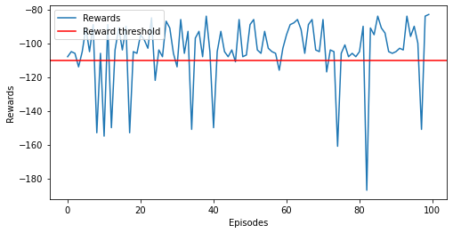

```python
plot_test(rewards_test_DQN[0], REWARD_THRESHOLD)
```

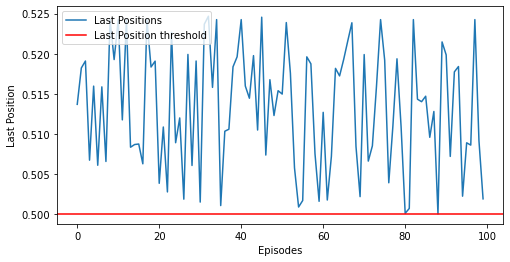

```python
plot_position(rewards_test_DQN[1], env.goal_position)
```

## 3. Agente DDQN (2.5 ptos)

En este apartado implementaremos una doble DQN con la misma red neuronal y características de la DQN del apartado anterior.

Recordemos que con la doble DQN, es la red principal la que elije la acción con mayor valor de Q, y la red objetivo la que proporciona el valor objetivo de Q para esa acción, es decir, la que dirá qué recompensa tiene esa acción elegida por la red principal.

Siguiendo el mismo esquema que en el ejercicio anterior, a continuación implementaremos una clase que defina el entrenamiento del agente teniendo en cuenta:

- La exploración/explotación (decaimiento de epsilon)
- La actualización y sincronización de la red principal y la red objetivo (pérdida)

Consideraremos que el agente ha aprendido a realizar la tarea (i.e. el "juego" termina) cuando obtiene una media de mínimo -110 puntos durante 100 episodios consecutivos.

**Ejercicio (1.5 ptos):** Implementar los siguientes puntos de la clase `DDQNAgent()`siguiendo el mismo esquema de implementación realizado con el método `DQNAgent()`

```python
from copy import deepcopy, copy
```

```python
class DDQNAgent:

    def __init__(self, env, main_network, buffer, reward_threshold, epsilon=0.1, eps_decay=0.99, batch_size=32):

        """
        Params
        ======
        env: entorno
        main_network: clase con la red neuronal diseñada
        target_network: red objetivo
        buffer: clase con el buffer de repetición de experiencias
        epsilon: epsilon
        eps_decay: epsilon decay
        batch_size: batch size
        nblock: bloque de los X últimos episodios de los que se calculará la media de recompensa
        reward_threshold: umbral de recompensa definido en el entorno
        """

        self.env = env
        self.main_network = main_network
        self.target_network = deepcopy(main_network) # red objetivo (copia de la principal)
        self.buffer = buffer
        self.epsilon = epsilon
        self.eps_decay = eps_decay
        self.batch_size = batch_size
        self.nblock = 100
        self.reward_threshold = reward_threshold

        self.initialize()


    def initialize(self):
        self.training_rewards = []
        self.training_loss = []
        self.update_loss = []
        self.mean_training_rewards = []
        self.sync_eps = []
        self.total_reward = 0
        self.step_count = 0
        self.last_position = []
        self.state0 = self.env.reset()
        self.epsilon_evolution = []



    def take_step(self, eps, mode='train'):
        if mode == 'explore':
            action = self.env.action_space.sample()  # acción aleatoria en el burn-in
        else:
            action = self.main_network.get_action(self.state0, eps) # acción a partir del valor de Q (elección de la acción con mejor Q)
            self.step_count += 1

        # Realización de la acción y obtención del nuevo estado y la recompensa
        new_state, reward, done, _ = self.env.step(action)
        self.total_reward += reward
        self.buffer.append(self.state0, action, reward, done, new_state) # guardar experiencia en el buffer
        self.state0 = new_state.copy()

        if done:
            self.last_position.append(self.state0[0])
            self.state0 = env.reset()
        return done
     ####


    ## Entrenamiento
    def train(self, gamma=0.99, max_episodes=50000,
              batch_size=32,
              dnn_update_frequency=4,
              dnn_sync_frequency=2000):

        self.gamma = gamma

        # Rellenamos el buffer con N experiencias aleatorias ()
        print("Filling replay buffer...")
        while self.buffer.burn_in_capacity() < 1:
            self.take_step(self.epsilon, mode='explore')


        episode = 0
        training = True
        print("Training...")
        while training:
            self.state0 = self.env.reset()
            self.total_reward = 0
            gamedone = False
            while gamedone == False:
                # El agente toma una acción
                gamedone = self.take_step(self.epsilon, mode='train')


                if self.step_count % dnn_update_frequency == 0:
                    self.update()


                if self.step_count % dnn_sync_frequency == 0:
                    self.target_network.load_state_dict(
                        self.main_network.state_dict())
                    self.sync_eps.append(episode)
                ####

                if gamedone:
                    episode += 1

                    self.epsilon_evolution.append(self.epsilon) # guardamos la evolución de epsilon
                    self.training_rewards.append(self.total_reward) # guardamos las recompensas obtenidas
                    self.training_loss.append(np.mean(self.update_loss)) # guardamos la pérdida
                    ####
                    self.update_loss = []


                    mean_rewards = np.mean(
                        self.training_rewards[-self.nblock:])
                    self.mean_training_rewards.append(mean_rewards)
                    ###

                    print("\rEpisode {:d} Mean Rewards {:.2f} Epsilon {}\t\t".format(
                        episode, mean_rewards, self.epsilon), end="")

                    # Comprobamos que todavía quedan episodios
                    if episode >= max_episodes:
                        training = False
                        print('\nEpisode limit reached.')
                        break

                    # Termina el juego si la media de recompensas ha llegado al umbral fijado para este juego
                    if mean_rewards >= self.reward_threshold:
                        training = False
                        print('\nEnvironment solved in {} episodes!'.format(
                            episode))
                        break


                    self.epsilon = max(self.epsilon * self.eps_decay, 0.01)
                    ####


    ## Cálculo de la pérdida
    def calculate_loss(self, batch):
        # Separamos las variables de la experiencia y las convertimos a tensores
        states, actions, rewards, dones, next_states = [i for i in batch]
        rewards_vals = torch.FloatTensor(rewards).reshape(-1,1)
        actions_vals = torch.LongTensor(np.array(actions)).reshape(-1,1)
        dones_t = torch.ByteTensor(dones)

        # Obtenemos los valores de Q de la red principal
        qvals = torch.gather(self.main_network.get_qvals(states), 1, actions_vals)

        #############################################################################
        #########DDQN update ################################################
        next_actions = torch.max(self.main_network.get_qvals(next_states), dim=-1)[1]
        next_actions_vals = torch.LongTensor(next_actions).reshape(-1,1)
        # Obtenemos los valores de Q de la red objetivo
        target_qvals = self.target_network.get_qvals(next_states)
        qvals_next = torch.gather(target_qvals, 1, next_actions_vals).detach()
        #####

        qvals_next[dones_t] = 0 # 0 en estados terminales

        # Calculamos ecuación de Bellman
        expected_qvals = self.gamma * qvals_next + rewards_vals

        # Calculamos la pérdida
        loss = torch.nn.MSELoss()(qvals, expected_qvals.reshape(-1,1))
        return loss


    def update(self):
        self.main_network.optimizer.zero_grad()  # eliminamos cualquier gradiente pasado
        batch = self.buffer.sample_batch(batch_size=self.batch_size) # seleccionamos un conjunto del buffer
        loss = self.calculate_loss(batch) # calculamos la pérdida
        loss.backward() # hacemos la diferencia para obtener los gradientes
        self.main_network.optimizer.step() # aplicamos los gradientes a la red neuronal
        # Guardamos los valores de pérdida
        self.update_loss.append(loss.detach().numpy())
```

A continuación entrenaremos el modelo con los mismos hiperparámetros que con la DQN.

**Ejercicio (0.25 ptos):** Entrenar el agente. Guardar el modelo entrenado en formato ".pth".

```python
# lr = 0.001          #Velocidad aprendizaje 0.00025
# MEMORY_SIZE = 10000   #Máxima capacidad del buffer 10000
# MAX_EPISODES = 5000   #Número máximo de episodios (el agente debe aprender antes de llegar a este valor)
# EPSILON = 1           #Valor inicial de epsilon
# EPSILON_DECAY = .99   #Decaimiento de epsilon 0.009
# GAMMA = 0.99          #Valor gamma de la ecuación de Bellman
# BATCH_SIZE = 32       #Conjunto a coger del buffer para la red neuronal
# BURN_IN = 1000        #Número de experiencias iniciales usadas para rellenar el buffer antes de entrenar
# DNN_UPD = 3           #Frecuencia de actualización de la red neuronal
# DNN_SYNC = 1000       #Frecuencia de sincronización de pesos entre red neuronal y red objetivo
```

```python
#buffer = experienceReplayBuffer(memory_size=MEMORY_SIZE, burn_in=BURN_IN)
#nn = NeuralNet(env, learning_rate=lr)
agentDDQN = DDQNAgent(env, nn, buffer, REWARD_THRESHOLD, EPSILON, EPSILON_DECAY, BATCH_SIZE)
```

```python
start_time = time.time()

##TODO:
agentDDQN.train(gamma=GAMMA, max_episodes=MAX_EPISODES,
              batch_size=BATCH_SIZE, dnn_update_frequency=DNN_UPD, dnn_sync_frequency=DNN_SYNC)

end_time = time.time()
print('Training time: ' + str(round((end_time-start_time)/60,2)) + " minutes")
```

```
Filling replay buffer...
Training...
```

```
Episode 446 Mean Rewards -109.80 Epsilon 0.011419881460400004
Environment solved in 446 episodes!
Training time: 3.63 minutes
```

```python
##TODO:
nn_filename = "agentDDQN_Trained_Model.pth"
torch.save(agentDDQN.main_network.state_dict(), nn_filename)
```

**Ejercicio (0.25 ptos):** Representar:

1. Gráfico con las recompensas obtenidas a lo largo del entrenamieno, la evolución de las recompensas medias cada 100 episodios, y el umbral de recompensa establecido por el entorno
2. Gráfico con la posición final del coche en cada episodio
3. Gráfico con la evolución de la perdida a lo largo del entrenamiento
4. Gráfico con la evolución de epsilon a lo largo del entrenamiento

Comentar los resultados obtenidos.

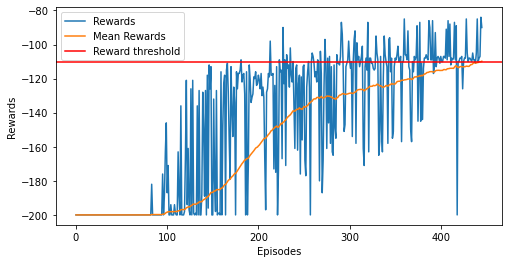

```python
plot_rewards(agentDDQN.training_rewards,agentDDQN.mean_training_rewards,REWARD_THRESHOLD)
```

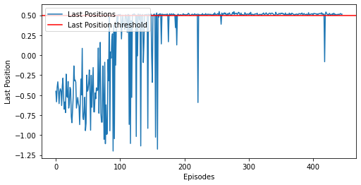

```python
plot_position(agentDDQN.last_position, env.goal_position)
```

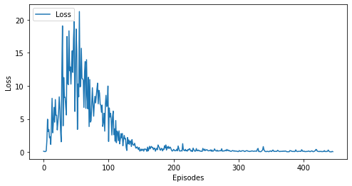

```python
plot_loss(agentDDQN.training_loss)
```

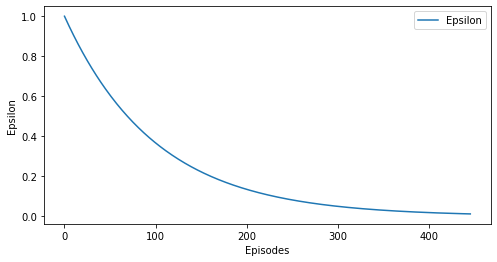

```python
plot_epsilon(agentDDQN.epsilon_evolution)
```

**Solución:**  
Aspectos a comentar:

1. Episodios necesarios para resolver el problema
2. Evolución del aprendizaje (continuo, variable, en algún punto deja de mejorar, siempre mejora, posición del coche, etc.)
3. Evolución del decaimiento de epsilon (exploración, explotación). Relación con el momento en qué el agente empieza a aprender?
4. ...

Una vez entrenado el agente, nos interesa comprobar cómo de bien ha aprendido, si el "robot" es capaz de realizar las tareas aprendidas. Para ello, recuperamos el modelo entrenado y dejamos que el agente tome acciones aleatorias según ese modelo y observamos su comportamiento.

**Ejercicio (0.5 ptos):** Cargar el modelo entrenado y ejecutar el agente entrenado durante 100 episodios consecutivos. Almacenar la posición final del agente en cada episodio, y calcular la suma de recompensas por cada episodio. Mostrar:

- un gráfico con la suma de las recompensas respecto de los episodios, incluyendo el umbral de recompensa establecido por el entorno
- un gráfico con la posición final del coche en cada episodio

Comentar los resultados obtenidos. --------------------------------------------------------------------------------------------------- *Opcional*: visualizar los episodios con `env.render()`, sólo posible en local. Esta visualización ralentiza el proceso unos segundos por episodio.

```python
##TODO:
agentDDQN.main_network.load_state_dict(torch.load('agentDDQN_Trained_Model.pth'))
```

```
<All keys matched successfully>
```

```python
rewards_test_DDQN = test_model(agentDDQN)
```

```
Episode 0	Average Score: -106.00 	Finished in 107 timesteps
 Episode 1	Average Score: -86.00 	Finished in 87 timesteps
 Episode 2	Average Score: -107.00 	Finished in 108 timesteps
 Episode 3	Average Score: -107.00 	Finished in 108 timesteps
 Episode 4	Average Score: -85.00 	Finished in 86 timesteps
 Episode 5	Average Score: -106.00 	Finished in 107 timesteps
 Episode 6	Average Score: -84.00 	Finished in 85 timesteps
 Episode 7	Average Score: -106.00 	Finished in 107 timesteps
 Episode 8	Average Score: -106.00 	Finished in 107 timesteps
 Episode 9	Average Score: -107.00 	Finished in 108 timesteps
 Episode 10	Average Score: -107.00 	Finished in 108 timesteps
 Episode 11	Average Score: -107.00 	Finished in 108 timesteps
 Episode 12	Average Score: -83.00 	Finished in 84 timesteps
 Episode 13	Average Score: -107.00 	Finished in 108 timesteps
 Episode 14	Average Score: -106.00 	Finished in 107 timesteps
 Episode 15	Average Score: -107.00 	Finished in 108 timesteps
 Episode 16	Average Score: -106.00 	Finished in 107 timesteps
 Episode 17	Average Score: -106.00 	Finished in 107 timesteps
 Episode 18	Average Score: -107.00 	Finished in 108 timesteps
 Episode 19	Average Score: -107.00 	Finished in 108 timesteps
 Episode 20	Average Score: -107.00 	Finished in 108 timesteps
 Episode 21	Average Score: -107.00 	Finished in 108 timesteps
 Episode 22	Average Score: -107.00 	Finished in 108 timesteps
 Episode 23	Average Score: -107.00 	Finished in 108 timesteps
 Episode 24	Average Score: -107.00 	Finished in 108 timesteps
 Episode 25	Average Score: -107.00 	Finished in 108 timesteps
 Episode 26	Average Score: -106.00 	Finished in 107 timesteps
 Episode 27	Average Score: -85.00 	Finished in 86 timesteps
 Episode 28	Average Score: -87.00 	Finished in 88 timesteps
 Episode 29	Average Score: -107.00 	Finished in 108 timesteps
 Episode 30	Average Score: -107.00 	Finished in 108 timesteps
 Episode 31	Average Score: -107.00 	Finished in 108 timesteps
 Episode 32	Average Score: -107.00 	Finished in 108 timesteps
 Episode 33	Average Score: -106.00 	Finished in 107 timesteps
 Episode 34	Average Score: -107.00 	Finished in 108 timesteps
 Episode 35	Average Score: -107.00 	Finished in 108 timesteps
 Episode 36	Average Score: -107.00 	Finished in 108 timesteps
 Episode 37	Average Score: -107.00 	Finished in 108 timesteps
 Episode 38	Average Score: -106.00 	Finished in 107 timesteps
 Episode 39	Average Score: -107.00 	Finished in 108 timesteps
```

[output cut: 45 more lines]

```
 Episode 85	Average Score: -107.00 	Finished in 108 timesteps
 Episode 86	Average Score: -84.00 	Finished in 85 timesteps
 Episode 87	Average Score: -86.00 	Finished in 87 timesteps
 Episode 88	Average Score: -107.00 	Finished in 108 timesteps
 Episode 89	Average Score: -106.00 	Finished in 107 timesteps
 Episode 90	Average Score: -106.00 	Finished in 107 timesteps
 Episode 91	Average Score: -87.00 	Finished in 88 timesteps
 Episode 92	Average Score: -84.00 	Finished in 85 timesteps
 Episode 93	Average Score: -104.00 	Finished in 105 timesteps
 Episode 94	Average Score: -107.00 	Finished in 108 timesteps
 Episode 95	Average Score: -107.00 	Finished in 108 timesteps
 Episode 96	Average Score: -89.00 	Finished in 90 timesteps
 Episode 97	Average Score: -84.00 	Finished in 85 timesteps
 Episode 98	Average Score: -86.00 	Finished in 87 timesteps
 Episode 99	Average Score: -107.00 	Finished in 108 timesteps
```

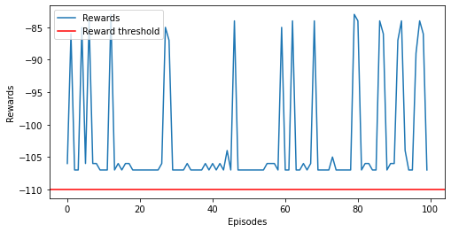

```python
plot_test(rewards_test_DDQN[0], REWARD_THRESHOLD)
```

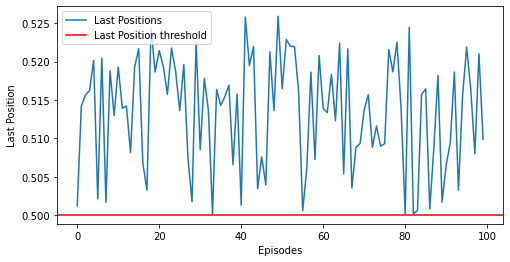

```python
plot_position(rewards_test_DDQN[1], env.goal_position)
```

## 4. REINFORCE con línea de base (2 ptos)

En este apartado implementaremos un modelo basado en Gradientes de Política, el método de REINFORCE con línea de base.

Utilizaremos un modelo Secuencial con la siguiente configuración:

- Tres capas completamente conectadas de 64, 32 y 16 neuronas respectivamente, `bias=True`, y activación tangencial
- Una capa de salida completamente conectada, `bias=True`, y activación Softmax (dim=-1)

Usaremos el optimizador Adam para entrenar la red.

**Ejercicio (0.25 ptos):** Implementar la clase `PGReinforce()`. Inicializar las variables necesarias y definir el modelo Secuencial de red neuronal indicado. ----------------------------------------------------------------------------------------------------------- **Nota**: se os proporciona el código pre-implementado. La implementación que se pide en el enunciado está indicada en los bloques *TODO* y/o con variables igualadas a *None*.

```python
class NeuralNetReinforce(torch.nn.Module):

    def __init__(self, env, learning_rate=1e-3):
        """
        Params
        ======
        n_inputs: tamaño del espacio de estadps
        n_outputs: tamaño del espacio de acciones
        learning_rate: velocidad aprendizaje
        """
        super(NeuralNetReinforce, self).__init__()

        ###################################
        ####TODO: Inicializar parámetros####
        self.n_inputs = env.observation_space.shape[0]
        self.n_outputs = env.action_space.n
        self.learning_rate = learning_rate


        #######################################
        ##TODO: Construcción de la red neuronal
        self.model = torch.nn.Sequential(
          torch.nn.Linear(self.n_inputs, 64, bias=True),
          torch.nn.Tanh(),
          torch.nn.Linear(64, 32, bias=True),
          torch.nn.Tanh(),
          torch.nn.Linear(32, 16, bias=True),
          torch.nn.Tanh(),
          torch.nn.Linear(16, self.n_outputs, bias=True),
          torch.nn.Softmax(dim=-1))


        #######################################
        ##TODO: Inicializar el optimizador
        self.optimizer = torch.optim.Adam(self.parameters(), lr=self.learning_rate)



    #Obtención de las probabilidades de las posibles acciones
    def get_action_prob(self, state):
        action_probs = self.model(torch.FloatTensor(state))
        return action_probs
```

A continuación definiremos el comportamiento del agente. En este caso no tendremos en cuenta el umbral de recompensa en la finalización del aprendizaje, sino **dejaremos al agente realizar el máximo de episodios establecido**.

**Ejercicio (0.75 ptos):** Implementar la clase `reinforceAgent()` teniendo en cuenta los siguientes puntos:

1. Inicializar parámetros
2. Inicializar las variables necesarias
3. Implementar la acción a tomar
4. Calcular el *discounted rewards* usando como línea de base la media del retorno estandarizada
5. Calcular la media de recompensas de los últimos 100 episodios
6. Actualizar red, almacenar pérdida y resetear variables cuando se completa el batch
7. Implementar la pérdida por actualización
8. Hacer las comprobaciones necesarias de fin de episodio

Además, durante el proceso se deben almacenar (*):

- Las recompensas obtenidas en cada paso del entrenamiento
- Las recompensas medias cada 100 episodios
- La posición final del coche en cada episodio
- La pérdida durante el entrenamiento

----------------------------------------------------------------------------------------------------------- **Nota**: se os proporciona el código pre-implementado. La implementación que se pide en el enunciado está indicada en los bloques *TODO* y/o con variables igualadas a *None*, salvo (*) en qué momento almacenar las variables que se indican.

```python
class reinforceAgent:

    def __init__(self, env, main_network):
        """
        Params
        ======
        env: entorno
        main_network: clase con la red neuronal diseñada
        nblock: bloque de los X últimos episodios de los que se calculará la media de recompensa
        """

        ###################################################
        ######TODO 1: inicializar parámetros ##################
        self.env = env
        self.main_network = main_network
        self.nblock = 100

        self.initialize()

    ###############################################################
    #####TODO 2: inicializar variables extra que se necesiten######:
    def initialize(self):
        self.batch_rewards = []
        self.batch_actions = []
        self.batch_states = []
        self.batch_counter = 1
        self.training_rewards = []
        self.training_loss = []
        self.update_loss = []
        self.mean_training_rewards = []


    ## Entrenamiento
    def train(self, gamma=0.99, max_episodes=2000, batch_size=10):
        self.gamma = gamma
        self.batch_size = batch_size

        episode = 0
        action_space = np.arange(self.env.action_space.n)
        training = True
        print("Training...")
        while training:
            state0 = env.reset()
            episode_states = [] #array para almacenar estados
            episode_rewards = [] #array para almacenar rewards
            episode_actions = [] #array para almacenar acciones
            gamedone = False

            while gamedone == False:
                ##########################################################
                ######TODO 3:  Tomar nueva acción ########################
                action_probs = self.main_network.get_action_prob(state0).detach().numpy() #distribución de probabilidad de las acciones dado el estado actual
                action = np.random.choice(action_space, p=action_probs) #acción aleatoria de la distribución de probabilidad
                next_state, reward, gamedone, _ = env.step(action)
                #######


                #TODO:  Almacenamos experiencias (estados, rewards y acciones) que se van obteniendo en este episodio
                episode_states.append(state0)
                episode_rewards.append(reward)
                episode_actions.append(action)

                state0 = next_state


                if gamedone:
                    episode += 1
                    # Calculamos el término del retorno menos la línea de base
                    self.batch_rewards.extend(self.discount_rewards(episode_rewards))
                    self.batch_states.extend(episode_states)
                    self.batch_actions.extend(episode_actions)


                    #####################################################################################
                    ###TODO 5: calcular media de recompensas de los últimos X episodios#####
                    self.training_rewards.append(sum(episode_rewards)) # guardamos las recompensas obtenidas
                    mean_rewards = np.mean(self.training_rewards[-self.nblock:])
                    self.mean_training_rewards.append(mean_rewards)
                    ######


                    #####################################################################################
                    ###TODO 6: Cuando se completa el tamaño del batch: actualizar la red (update), almacenar
                    #la pérdida del entrenamiento, y resetear las variables del episodio necesarias
                    if self.batch_counter == self.batch_size:
                        self.update(self.batch_states, self.batch_rewards, self.batch_actions)
                        self.training_loss.append(np.mean(self.update_loss)) # guardamos la pérdida
                        self.update_loss = []

                        #TODO: Reseteamos las variables del epsiodio
                        self.batch_rewards = []
                        self.batch_actions = []
                        self.batch_states = []
                        self.batch_counter = 1


                    self.batch_counter += 1
                    print("\rEpisode {:d} Mean Rewards {:.2f}\t\t".format(
                        episode, mean_rewards), end="")

                    #####################################################################################
                    ###TODO 8:Hacer las comprobaciones necesarias de fin de episodio
                    if episode >= max_episodes:
                        training = False
                        print('\nEpisode limit reached.')
                        print('\nEnvironment solved in {} episodes!'.format(
                            episode))
                        break

    ########################################################
    ###TODO 4: cálculo del retorno menos la línea de base###
    def discount_rewards(self, rewards):
        discount_r = np.zeros_like(rewards)
        timesteps = range(len(rewards))
        reward_sum = 0
        for i in reversed(timesteps):
            reward_sum = rewards[i] + self.gamma*reward_sum
            discount_r[i] = reward_sum
        baseline = discount_r - np.mean(discount_r)
        baseline = baseline / np.std(discount_r)
        return baseline



    #################################################
    ###TODO 7: Cálculo de la pérdida#################
    # Recordatorio: cada actualización es proporcional al producto del retorno y el gradiente de la probabilidad
    # de tomar la acción tomada, dividido por la probabilidad de tomar esa acción (logaritmo natural)
    def calculate_loss(self, state_t, action_t, reward_t):
        logprob = torch.log(self.main_network.get_action_prob(state_t))
        selected_logprobs = reward_t * \
                        logprob[np.arange(len(action_t)), action_t]
        loss = -selected_logprobs.mean()
        return loss


    ## Actualización
    def update(self, batch_s, batch_r, batch_a):
        self.main_network.optimizer.zero_grad()  # eliminamos cualquier gradiente pasado
        state_t = torch.FloatTensor(batch_s)
        reward_t = torch.FloatTensor(batch_r)
        action_t = torch.LongTensor(batch_a)
        loss = self.calculate_loss(state_t, action_t, reward_t) # calculamos la pérdida
        loss.backward() # hacemos la diferencia para obtener los gradientes
        self.main_network.optimizer.step() # aplicamos los gradientes a la red neuronal
        # Guardamos los valores de pérdida
        self.update_loss.append(loss.detach().numpy())
```

A continuación entrenaremos el modelo con los siguientes hiperparámetros:

- Velocidad de aprendizaje: 0.01
- Tamaño del batch: 8
- Gamma: 0.99
- Número máximo de episodios: 5000

**Ejercicio (0.1 ptos):** Definir los hiperparámetros, cargar el modelo de red neuronal y entrenar el agente

```python
##TODO:
lr = 0.01           #Velocidad aprendizaje
MAX_EPISODES = 5000  #Número máximo de episodios (el agente debe aprender antes de llegar a este valor)
GAMMA = 0.99
BATCH_SIZE = 8
```

```python
pgR = NeuralNetReinforce(env, learning_rate=lr)
```

```python
agentPG = reinforceAgent(env, pgR)
```

```python
start_time = time.time()

agentPG.train(gamma=GAMMA, max_episodes=MAX_EPISODES, batch_size=BATCH_SIZE)

end_time = time.time()
print('Training time: ' + str(round((end_time-start_time)/60,2)) + " minutes")
```

```
Training...
Episode 5000 Mean Rewards -200.00
Episode limit reached.

Environment solved in 5000 episodes!
Training time: 6.15 minutes
```

**Análisis (0.2 ptos):** ¿Qué ha ocurrido? ¿El agente es capaz de aprender la tarea? ¿Por qué?

**Solución:**  
Como puede verse, el agente no es capaz de solucionar el entorno. Esto se debe a que este entorno sólo otorga una recompensa al final del episodio, lo que provoca que el agente no sepa cuándo está utilizando una política que puede repercutir en un mayor retorno.

### 4.1 Modificación de la recompensa

Como hemos visto, el entorno de MountainCar únicamente proporciona recompensa cuando el agente llega al objetivo. Pero no hay otras indicaciones que permitan al agente saber que está yendo en la buena dirección de aprendizaje, lo que hace el aprendizaje un poco aleatorio y difícil para el agente.

En este apartado vamos a modificar la recompensa del agente REINFORCE creando una función que dé al agente una recompensa según la posición en la que se encuentra. Que aunque no llegue al objetivo final pueda al menos saber que no iba tan mal encaminado.

**Ejercicio (0.25 ptos):** Definir una función `get_reward()` en la que, si el agente se encuentra:

- en una posición mayor o igual a 0.5, la recompensa será: +10
- en una posición mayor que -0.4, la recompensa será: $(1+s)^2$ , es decir, proporcional a la posición
- en cualquier otra posición, se le penalizará con una recompensa de: -1

```python
##TODO
def get_reward(state):
    if state[0] >= 0.5:
        return 10
    if state[0] > -0.4:
        return (1+state[0])**2
    return -1
```

**Ejercicio (0.25 ptos):** Modificar la clase `reinforceAgent` del ejercicio anterior para que el agente reciba las nuevas recompensas. Entrenar el agente con los mismos parámetros que en el ejercicio anterior, y mostrar las gráficas de recompensas y de la posición final del coche en cada episodio.

```python
class reinforceAgentNewRw:

    ###################################################
    ######TODO 1: declarar variables ##################
    def __init__(self, env, main_network):
        """
        Params
        ======
        env: entorno
        main_network: clase con la red neuronal diseñada
        nblock: bloque de los X últimos episodios de los que se calculará la media de recompensa
        reward_threshold: umbral de recompensa definido en el entorno
        """
        self.env = env
        self.main_network = main_network
        self.nblock = 100

        self.initialize()
     #######

    ###############################################################
    #####TODO 2: inicializar variables extra que se necesiten######:
    def initialize(self):
        self.batch_rewards = []
        self.batch_actions = []
        self.batch_states = []
        self.batch_counter = 1
        self.training_rewards = []
        self.training_loss = []
        self.update_loss = []
        self.mean_training_rewards = []
        self.last_position = []
    ######



    ## Entrenamiento
    def train(self, gamma=0.99, max_episodes=2000, batch_size=10):
        self.gamma = gamma
        self.batch_size = batch_size

        episode = 0
        action_space = np.arange(self.env.action_space.n)
        training = True
        print("Training...")
        while training:
            state0 = env.reset()
            episode_states = []
            episode_rewards = []
            episode_actions = []
            gamedone = False

            while gamedone == False:
                ##########################################################
                ######TODO 3:  Tomar nueva acción ########################
                action_probs = self.main_network.get_action_prob(state0).detach().numpy() #distribución de probabilidad de las acciones dado el estado actual
                action = np.random.choice(action_space, p=action_probs) #acción aleatoria de la distribución de probabilidad
                next_state, reward, gamedone, _ = env.step(action)
                reward = get_reward(next_state)
                #######


                # Almacenamos experiencias que se van obteniendo en este episodio
                episode_states.append(state0)
                episode_rewards.append(reward)
                episode_actions.append(action)

                state0 = next_state


                if gamedone:
                    episode += 1
                    # Calculamos el término del retorno menos la línea de base
                    self.batch_rewards.extend(self.discount_rewards(episode_rewards))
                    self.batch_states.extend(episode_states)
                    self.batch_actions.extend(episode_actions)


                    #####################################################################################
                    ###TODO 5: calcular media de recompensas de los últimos X episodios, y almacenar#####
                    self.training_rewards.append(sum(episode_rewards)) # guardamos las recompensas obtenidas
                    mean_rewards = np.mean(self.training_rewards[-self.nblock:])
                    self.mean_training_rewards.append(mean_rewards)
                    self.last_position.append(state0[0])
                    ######


                    # Actualizamos la red cuando se completa el tamaño del batch
                    if self.batch_counter == self.batch_size:
                        self.update(self.batch_states, self.batch_rewards, self.batch_actions)

                        ####################################
                        ###TODO : almacenar training_loss###
                        self.training_loss.append(np.mean(self.update_loss)) # guardamos la pérdida
                        ###########

                        self.update_loss = []

                        # Reseteamos las variables del epsiodio
                        self.batch_rewards = []
                        self.batch_actions = []
                        self.batch_states = []
                        self.batch_counter = 1

                    self.batch_counter += 1
                    print("\rEpisode {:d} Mean Rewards {:.2f}\t\t".format(
                        episode, mean_rewards), end="")

                    # Comprobamos que todavía quedan episodios
                    if episode >= max_episodes:
                        training = False
                        print('\nEpisode limit reached.')
                        print('\nEnvironment solved in {} episodes!'.format(
                            episode))
                        break


    ########################################################
    ###TODO 4: cálculo del retorno menos la línea de base###
    def discount_rewards(self, rewards):
        discount_r = np.zeros_like(rewards)
        timesteps = range(len(rewards))
        reward_sum = 0
        for i in reversed(timesteps):
            reward_sum = rewards[i] + self.gamma*reward_sum
            discount_r[i] = reward_sum
        baseline = discount_r - np.mean(discount_r)
        baseline = baseline / np.std(discount_r)
        return baseline
    ##########


    ## Actualización
    def update(self, batch_s, batch_r, batch_a):
        self.main_network.optimizer.zero_grad()  # eliminamos cualquier gradiente pasado
        state_t = torch.FloatTensor(batch_s)
        reward_t = torch.FloatTensor(batch_r)
        action_t = torch.LongTensor(batch_a)
        loss = self.calculate_loss(state_t, action_t, reward_t) # calculamos la pérdida
        loss.backward() # hacemos la diferencia para obtener los gradientes
        self.main_network.optimizer.step() # aplicamos los gradientes a la red neuronal
        # Guardamos los valores de pérdida
        self.update_loss.append(loss.detach().numpy())

    #################################################
    ###TODO 5: Cálculo de la pérdida#################
    # Recordatorio: cada actualización es proporcional al producto del retorno y el gradiente de la probabilidad
    # de tomar la acción tomada, dividido por la probabilidad de tomar esa acción (logaritmo natural)
    def calculate_loss(self, state_t, action_t, reward_t):
        logprob = torch.log(self.main_network.get_action_prob(state_t))
        selected_logprobs = reward_t * \
                        logprob[np.arange(len(action_t)), action_t]
        loss = -selected_logprobs.mean()
        return loss
     ########
```

```python
pgR_NewRw = NeuralNetReinforce(env, learning_rate=lr)
```

```python
agentPG_NewRw = reinforceAgentNewRw(env, pgR_NewRw)
```

```python
start_time = time.time()

agentPG_NewRw.train(gamma=GAMMA, max_episodes=MAX_EPISODES, batch_size=BATCH_SIZE)

end_time = time.time()
print('Training time: ' + str(round((end_time-start_time)/60,2)) + " minutes")
```

```
Training...
Episode 5000 Mean Rewards -23.54
Episode limit reached.

Environment solved in 5000 episodes!
Training time: 5.74 minutes
```

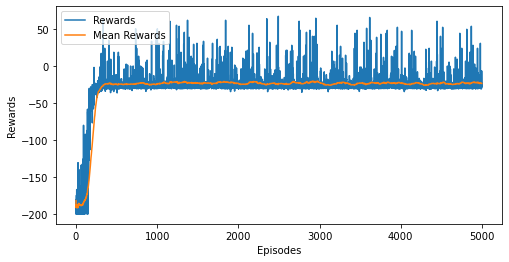

```python
plt.figure(figsize=(8,4))
plt.plot(agentPG_NewRw.training_rewards, label='Rewards')
plt.plot(agentPG_NewRw.mean_training_rewards, label='Mean Rewards')
plt.xlabel('Episodes')
plt.ylabel('Rewards')
plt.legend(loc="upper left")
plt.show()
```

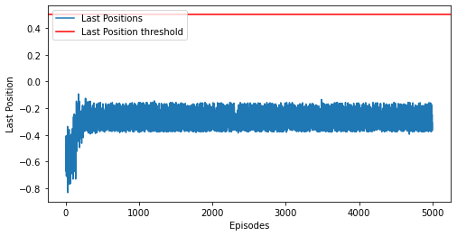

```python
plot_position(agentPG_NewRw.last_position, env.goal_position)
```

**Análisis (0.2 ptos):** Comentar los resultados obtenidos. ¿Ha conseguido el agente REINFORCE aprender a llegar al objetivo? Indicar qué se podría hacer para mejorar el resultado.

**Solución:**  
Como puede verse, el agente no es capaz de solucionar el entorno. Aunque las recompensas evolucionan favorablemente y en pocos episodios se supera el umbral de -110 (que ya no es válido porque hemos cambiado el sistema de recompensas) llegando a mantenerse entorno a -25, pero lo hace (tal y como puede verse en la gráfica de las posiciones) a base de ir hacia la derecha y mantenerse en posiciones entre -0.4 y -0.1, insuficiente para llegar al objetivo. La solución pasa por modificar de nuevo el sistema de recompensas y tener en cuenta otros factores (velocidad, recompensas más progresivas, ...)

## 5. Comparación de modelos (0.5 ptos)

**Ejercicio:** Mostrar en un mismo gráfico la evolución de la media de recompensas de los modelos DQN y DDQN, junto con el umbral de recompensa. Comentar los resultados.

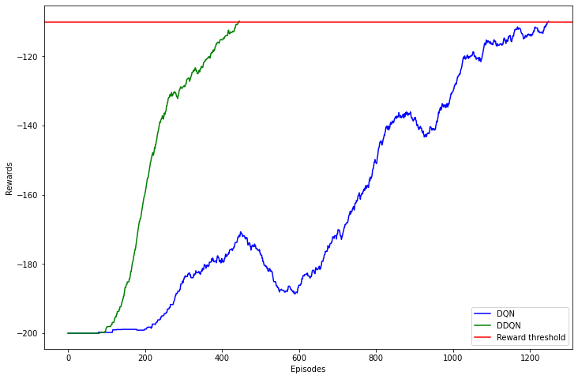

```python
plt.figure(figsize=(12,8))
plt.plot(agentDQN.mean_training_rewards, color='blue', label='DQN')
plt.plot(agentDDQN.mean_training_rewards, color='green', label='DDQN')
plt.axhline(REWARD_THRESHOLD, color='r', label="Reward threshold")
plt.xlabel('Episodes')
plt.ylabel('Rewards')
plt.legend(loc="lower right")
plt.show()
```

**Solución:**  
Aspectos a comparar y razonar entre los dos modelos:

1. Tiempo de aprendizaje total / número de episodios necesarios
2. Episodios necesarios para aprender a ponerse sobre el suelo (no necesariamente en la pista)
3. Variabilidad o continuidad en el proceso de aprendizaje y comentar el por qué en cada caso
4. Justificación del modelo que se elegiría
5. ...

## 6. Creación de un entorno en Gym (2 ptos)

En este ejercicio diseñaremos un entorno sencillo siguiendo el esquema de los entornos de `gym`, y trataremos de resolverlo.

Los entornos de `gym` suelen tener la siguiente estructura:

```
class FooEnv(gym.Env):
  metadata = {'render.modes': ['human']}

  def __init__(self):
    ...
  def step(self, action):
    ...
  def reset(self):
    ...
  def render(self, mode='human', close=False):
    ...
```

Para nuestro entorno usaremos todas estas funciones salvo el `render` (relativo al diseño de la visualización el entorno).

Primeramente importamos la librerías necesarias:

```python
from gym import Env
from gym.spaces import Discrete, Box
import numpy as np
import random
```

### 6.1 Entorno

El entorno que vamos a diseñar consiste en un regulador de temperatura. Imaginemos que queremos tener una ducha inteligente que sea capaz de mantener la temperatura en un intervalo concreto (37-39 grados) durante todo el tiempo de baño que fijemos. Cada acción será subir o bajar la temperatura un grado, o mantener la temperatura actual.

Concretamente queremos que el regulador de temperatura tenga las siguientes características:

- La temperatura (i.e. estado) puede oscilar entre los 0 y los 100 grados
- La temperatura inicial (i.e. estado inicial) será de 38+-3 grados
- La duración del baño debe ser de 3 minutos (180 segundos)
- Las acciones posibles seran:
  - 0 : bajar temperatura un grado
  - 1 : mantener temperatura
  - 2 : subir temperatura un grado

**Ejercicio (0.75 ptos):** Diseñar el entorno `TempControlEnv` con las características indicadas.

```python
class TempControlEnv(Env):
    def __init__(self):
        '''
        Argumentos:
            - espacio de acciones
            - espacio de observaciones (se recomienda usar la función Box)
            - estado inicial
            - duración episodio
        '''
         ###TODO: inicializar variables###
        self.action_space = Discrete(3) #acciones posibles
        self.min_temp = np.array([0])
        self.max_temp = np.array([100])
        self.observation_space = Box(low=self.min_temp, high=self.max_temp) #vector de temperatura
        self.state = 38 + random.randint(-3,3) #temperatura inicial
        self.bath_time = 180 #tiempo del baño (episodio)

    def step(self, action):
        '''
        Argumentos:
            - temperatura según acción tomada
            - disminución tiempo de baño
        '''

        ###TODO: nueva temperatura y còmput de reducción del tiempo de baño###
        self.state += action -1
        self.bath_time -= 1

        # Comprobar límites temperatura
        if self.state < self.min_temp:
                self.state = self.min_temp
        elif self.state > self.max_temp:
            self.state = self.max_temp

        ###TODO: Cálculo de las recompensas###
        if self.state >=37 and self.state <=39:
            reward =1
        else:
            reward = -1


        ###TODO: Comprobar si el tiempo de baño se ha agotado###
        if self.bath_time <= 0:
            done = True
        else:
            done = False


        # Aplicamos ruido a la temperatura (exe: alguien abre el agua caliente de otro grifo
        # y altera la temperatura del agua de nuestra ducha)
        self.state += random.randint(-1,1)

        # Set placeholder for info
        info = {}

        # Return step information
        return self.state, reward, done, info


    def reset(self):
        '''
        Argumentos:
            - resetear temperatura inicial
            - resetear tiempo de baño
        '''
        ###TODO: resetear variables
        self.state = 38 + random.randint(-3,3)
        self.bath_time = 180
        return self.state
```

**Ejercicio (0.25 ptos):** Cargar el entorno `TempControlEnv` y mostrar el espacio de acciones y el espacio de observaciones. Ejecutar 10 episodios con acciones aleatorias, mostrando el episodio y la recompensa obtenida.

```python
env = TempControlEnv()
```

```python
# Espacio de acciones
print("Espacio de acciones es {} ".format(env.action_space))

# Espacio de observacions
print("Espacio de estados es {} ".format(env.observation_space))
```

```
Espacio de acciones es Discrete(3)
Espacio de estados es Box([0.], [100.], (1,), float32)
```

```python
episodes = 10
for episode in range(1, episodes+1):
    state = env.reset()
    done = False
    score = 0

    while not done:
        #env.render()
        action = env.action_space.sample()
        n_state, reward, done, info = env.step(action)
        score+=reward
    print('Episode:{} Reward:{}'.format(episode, score))
```

```
Episode:1 Reward:-148
Episode:2 Reward:-152
Episode:3 Reward:-180
Episode:4 Reward:-148
Episode:5 Reward:-166
Episode:6 Reward:-90
Episode:7 Reward:-150
Episode:8 Reward:-166
Episode:9 Reward:-160
Episode:10 Reward:-94
```

### 6.2 Agente regulador de la temperatura

**Ejercicio (1 pto):** Implementar un agente capaz de regular la temperatura y mantenerla en los intervalos establecidos por el entorno `TempControlEnv` diseñado. Se puede implementar cualquier tipo de agente visto en el curso (módulos 9, 10 y 11) con los hiperparámetros que se considere conveniente.

- Mostrar gráficamente la evolución de las recompensas
- Mostrar gráficamente la evolución de la temperatura final de cada episodio a lo largo del entrenamiento
- Testear el modelo de agente con 100 episodios y mostrar las gráficas de recompensas y temperatura

```python
##SOLUCIÓN POSIBLE: Podemos adaptar la DQN del primer ejercicio, teniendo en cuenta que el estado ahora no es una tupla como en MountainCar,
# y que el entorno no tiene ningún reward_threshold definido (aunque se podría resolver con un threshold de 160 más o menos)

class NeuralNetControlTemp(torch.nn.Module):

    ###################################
    ###inicialización y modelo###
    def __init__(self, env, learning_rate=1e-3):

        """
        Params
        ======
        n_inputs: tamaño del espacio de estadps
        n_outputs: tamaño del espacio de acciones
        actions: array de acciones posibles
        """
        super(NeuralNetControlTemp, self).__init__()
        self.n_inputs = env.observation_space.shape[0]
        self.n_outputs = env.action_space.n
        self.actions = np.arange(env.action_space.n)
        self.learning_rate = learning_rate


        #######################################
        ##Construcción de la red neuronal
        self.model = torch.nn.Sequential(
            torch.nn.Linear(self.n_inputs, 128, bias=True),
            torch.nn.ReLU(),
            torch.nn.Linear(128, 64, bias=True),
            torch.nn.ReLU(),
            torch.nn.Linear(64, self.n_outputs, bias=True))


        #######################################
        ##Inicializar el optimizador
        self.optimizer = torch.optim.Adam(self.parameters(), lr=self.learning_rate)


    ### Método e-greedy
    def get_action(self, state, epsilon=0.05):
        if np.random.random() < epsilon:
            action = np.random.choice(self.actions)  # acción aleatoria
        else:
            qvals = self.get_qvals(state)  # acción a partir del cálculo del valor de Q para esa acción
            action= torch.max(qvals, dim=-1)[1].item()
        return action


    def get_qvals(self, state):
        if type(state) is tuple:
            state = np.array([np.ravel(s) for s in state])
        else:
            state = [state]  #If state is just a single value (like temperature here)
        state_t = torch.FloatTensor(state)
        return self.model(state_t)
```

```python
class DQNAgentTemp:

    def __init__(self, env, main_network, buffer, epsilon=0.1, eps_decay=0.99, batch_size=32):

        self.env = env
        self.main_network = main_network
        self.target_network = deepcopy(main_network) # red objetivo (copia de la principal)
        self.buffer = buffer
        self.epsilon = epsilon
        self.eps_decay = eps_decay
        self.batch_size = batch_size
        self.nblock = 100 # bloque de los X últimos episodios de los que se calculará la media de recompensa
        self.initialize()


    def initialize(self):
        self.update_loss = []
        self.training_rewards = []
        self.mean_training_rewards = []
        self.sync_eps = []
        self.total_reward = 0
        self.step_count = 0
        self.state0 = self.env.reset()
        self.final_temp = []


    ## Tomar nueva acción
    def take_step(self, eps, mode='train'):
        if mode == 'explore':
            # acción aleatoria en el burn-in y en la fase de exploración (epsilon)>
            action = self.env.action_space.sample()
        else:
            # acción a partir del valor de Q (elección de la acción con mejor Q)
            action = self.main_network.get_action(self.state0, eps)
            self.step_count += 1
        # Realización de la acción y obtención del nuevo estado y la recompensa
        new_state, reward, done, _ = self.env.step(action)
        self.total_reward += reward
        self.buffer.append(self.state0, action, reward, done, new_state) # guardar experiencia en el buffer
        self.state0 = new_state

        if done:
            self.final_temp.append(self.state0)
            self.state0 = env.reset()
        return done



    ## Entrenamiento
    def train(self, gamma=0.99, max_episodes=50000,
              batch_size=32,
              dnn_update_frequency=4,
              dnn_sync_frequency=2000):

        self.gamma = gamma

        # Rellenamos el buffer con N experiencias aleatorias ()
        print("Filling replay buffer...")
        while self.buffer.burn_in_capacity() < 1:
            self.take_step(self.epsilon, mode='explore')


        episode = 0
        training = True
        print("Training...")
        while training:
            self.state0 = self.env.reset()
            self.total_reward = 0
            gamedone = False
            while gamedone == False:
                # El agente toma una acción
                gamedone = self.take_step(self.epsilon, mode='train')
                # Actualizamos la red principal según la frecuencia establecida
                if self.step_count % dnn_update_frequency == 0:
                    self.update()
                # Sincronizamos red principal y red objetivo según la frecuencia establecida
                if self.step_count % dnn_sync_frequency == 0:
                    self.target_network.load_state_dict(
                        self.main_network.state_dict())
                    self.sync_eps.append(episode)


                if gamedone:
                    episode += 1
                    self.training_rewards.append(self.total_reward) # guardamos las recompensas obtenidas
                    self.update_loss = []

                    mean_rewards = np.mean(
                        self.training_rewards[-self.nblock:])
                    self.mean_training_rewards.append(mean_rewards)

                    print("\rEpisode {:d} Mean Rewards {:.2f} Epsilon {}\t\t".format(
                        episode, mean_rewards, self.epsilon), end="")

                    # Comprobamos que todavía quedan episodios
                    if episode >= max_episodes:
                        training = False
                        print('\nEpisode limit reached.')
                        print('\nEnvironment solved in {} episodes!'.format(
                            episode))
                        break


                    # Actualizar epsilon según la velocidad de decaimiento fijada
                    self.epsilon = max(self.epsilon * self.eps_decay, 0.01)


    ## Cálculo de la pérdida
    def calculate_loss(self, batch):
      #  print('loss')
        # Separamos las variables de la experiencia y las convertimos a tensores
        states, actions, rewards, dones, next_states = [i for i in batch]
        rewards_vals = torch.FloatTensor(rewards)
        actions_vals = torch.LongTensor(np.array(actions)).reshape(-1,1)
        dones_t = torch.ByteTensor(dones)
        # Obtenemos los valores de Q de la red principal
        qvals = torch.gather(self.main_network.get_qvals(states), 1, actions_vals)
        # Obtenemos los valores de Q objetivo. El parámetro detach() evita que estos valores actualicen la red objetivo
        qvals_next = torch.max(self.target_network.get_qvals(next_states),
                               dim=-1)[0].detach()
        qvals_next[dones_t] = 0 # 0 en estados terminales

        # Calculamos ecuación de Bellman
        expected_qvals = self.gamma * qvals_next + rewards_vals

        # Calculamos la pérdida
        loss = torch.nn.MSELoss()(qvals, expected_qvals.reshape(-1,1))
        return loss



    def update(self):
        self.main_network.optimizer.zero_grad()  # eliminamos cualquier gradiente pasado
        batch = self.buffer.sample_batch(batch_size=self.batch_size) # seleccionamos un conjunto del buffer
        loss = self.calculate_loss(batch) # calculamos la pérdida
        loss.backward() # hacemos la diferencia para obtener los gradientes
        self.main_network.optimizer.step() # aplicamos los gradientes a la red neuronal
        # Guardamos los valores de pérdida
        self.update_loss.append(loss.detach().numpy())
```

```python
lr = 0.001          #Velocidad aprendizaje 0.001
MEMORY_SIZE = 10000   #Máxima capacidad del buffer 10000
MAX_EPISODES = 3000   #Número máximo de episodios (el agente debe aprender antes de llegar a este valor)
EPSILON = 1           #Valor inicial de epsilon
EPSILON_DECAY = .99   #Decaimiento de epsilon 0.009
GAMMA = 0.99          #Valor gamma de la ecuación de Bellman
BATCH_SIZE = 32       #Conjunto a coger del buffer para la red neuronal
BURN_IN = 1000        #Número de experiencias iniciales usadas para rellenar el buffer antes de entrenar
DNN_UPD = 1           #Frecuencia de actualización de la red neuronal
DNN_SYNC = 10       #Frecuencia de sincronización de pesos entre red neuronal y red objetivo
#REWARD_THRESHOLD=160 #se podría poner un threshold de 160
```

```python
buffer = experienceReplayBuffer(memory_size=MEMORY_SIZE, burn_in=BURN_IN)
nn = NeuralNetControlTemp(env, learning_rate=lr)
agentDQNTemp = DQNAgentTemp(env, nn, buffer, EPSILON, EPSILON_DECAY, BATCH_SIZE)
```

```python
start_time = time.time()

##TODO:
agentDQNTemp.train(gamma=GAMMA, max_episodes=MAX_EPISODES,
              batch_size=BATCH_SIZE, dnn_update_frequency=DNN_UPD, dnn_sync_frequency=DNN_SYNC)

end_time = time.time()
print('Training time: ' + str(round((end_time-start_time)/60,2)) + " minutes")
```

```
Filling replay buffer...
Training...
```

```
Episode 3000 Mean Rewards 152.66 Epsilon 0.01		118606165716
Episode limit reached.

Environment solved in 3000 episodes!
Training time: 38.75 minutes
```

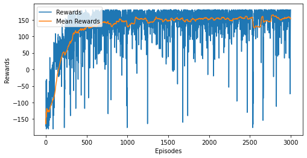

```python
plt.figure(figsize=(8,4))
plt.plot(agentDQNTemp.training_rewards, label='Rewards')
plt.plot(agentDQNTemp.mean_training_rewards, label='Mean Rewards')
plt.xlabel('Episodes')
plt.ylabel('Rewards')
plt.legend(loc="upper left")
plt.show()
```

```python
def plot_temperature(temperature):
    plt.figure(figsize=(8,4))
    plt.plot(temperature)
    plt.axhline(38, color='r', label="Ideal temperature")
    plt.xlabel('Episodes')
    plt.ylabel('Last temperature')
    plt.show()
```

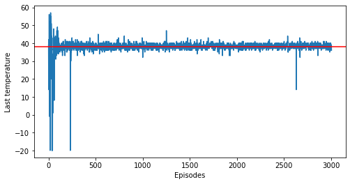

```python
plot_temperature(agentDQNTemp.final_temp)
```

```python
### Guardamos el modelo y lo testeamos con 100 episodios
nn_filename = "agentDQNTemp_Trained_Model.pth"
torch.save(agentDQNTemp.main_network.state_dict(), nn_filename)
```

```python
agentDQNTemp.main_network.load_state_dict(torch.load('agentDQNTemp_Trained_Model.pth'))
```

```
<All keys matched successfully>
```

```python
def test_model(ag):
    all_rewards = []
    last_temp = []
    for i_episode in range(100):
        observation = env.reset()

        total_reward = 0
    #episode loop
        t=0
        while True:
            #env.render()
            action = ag.main_network.get_action(observation, epsilon=0.0)
            observation, reward, done, info = env.step(action)
            total_reward += reward
            t=t+1
            if done:
                last_temp.append(observation)
                all_rewards.append(total_reward)
                break
        print('Episode {}\tAverage Score: {:.2f} \tFinished in {} timesteps \n '.format(i_episode, total_reward, t+1), end="")

    env.close()

    return all_rewards, last_temp
```

```python
rewards_test_DQNTemp = test_model(agentDQNTemp)
```

```
Episode 0	Average Score: 180.00 	Finished in 181 timesteps
 Episode 1	Average Score: 180.00 	Finished in 181 timesteps
 Episode 2	Average Score: 180.00 	Finished in 181 timesteps
 Episode 3	Average Score: 180.00 	Finished in 181 timesteps
 Episode 4	Average Score: 180.00 	Finished in 181 timesteps
 Episode 5	Average Score: 180.00 	Finished in 181 timesteps
 Episode 6	Average Score: 180.00 	Finished in 181 timesteps
 Episode 7	Average Score: 180.00 	Finished in 181 timesteps
 Episode 8	Average Score: 180.00 	Finished in 181 timesteps
 Episode 9	Average Score: 176.00 	Finished in 181 timesteps
 Episode 10	Average Score: 180.00 	Finished in 181 timesteps
 Episode 11	Average Score: 180.00 	Finished in 181 timesteps
 Episode 12	Average Score: 180.00 	Finished in 181 timesteps
 Episode 13	Average Score: 176.00 	Finished in 181 timesteps
 Episode 14	Average Score: 178.00 	Finished in 181 timesteps
 Episode 15	Average Score: 180.00 	Finished in 181 timesteps
 Episode 16	Average Score: 180.00 	Finished in 181 timesteps
 Episode 17	Average Score: 178.00 	Finished in 181 timesteps
 Episode 18	Average Score: 180.00 	Finished in 181 timesteps
 Episode 19	Average Score: 180.00 	Finished in 181 timesteps
 Episode 20	Average Score: 176.00 	Finished in 181 timesteps
 Episode 21	Average Score: 178.00 	Finished in 181 timesteps
 Episode 22	Average Score: 180.00 	Finished in 181 timesteps
 Episode 23	Average Score: 180.00 	Finished in 181 timesteps
 Episode 24	Average Score: 180.00 	Finished in 181 timesteps
 Episode 25	Average Score: 180.00 	Finished in 181 timesteps
 Episode 26	Average Score: 180.00 	Finished in 181 timesteps
 Episode 27	Average Score: 180.00 	Finished in 181 timesteps
 Episode 28	Average Score: 180.00 	Finished in 181 timesteps
 Episode 29	Average Score: 180.00 	Finished in 181 timesteps
 Episode 30	Average Score: 180.00 	Finished in 181 timesteps
 Episode 31	Average Score: 180.00 	Finished in 181 timesteps
 Episode 32	Average Score: 180.00 	Finished in 181 timesteps
 Episode 33	Average Score: 180.00 	Finished in 181 timesteps
 Episode 34	Average Score: 180.00 	Finished in 181 timesteps
 Episode 35	Average Score: 180.00 	Finished in 181 timesteps
 Episode 36	Average Score: 180.00 	Finished in 181 timesteps
 Episode 37	Average Score: 180.00 	Finished in 181 timesteps
 Episode 38	Average Score: 180.00 	Finished in 181 timesteps
 Episode 39	Average Score: 178.00 	Finished in 181 timesteps
```

[output cut: 45 more lines]

```
 Episode 85	Average Score: 180.00 	Finished in 181 timesteps
 Episode 86	Average Score: 180.00 	Finished in 181 timesteps
 Episode 87	Average Score: 178.00 	Finished in 181 timesteps
 Episode 88	Average Score: 180.00 	Finished in 181 timesteps
 Episode 89	Average Score: 180.00 	Finished in 181 timesteps
 Episode 90	Average Score: 178.00 	Finished in 181 timesteps
 Episode 91	Average Score: 180.00 	Finished in 181 timesteps
 Episode 92	Average Score: 180.00 	Finished in 181 timesteps
 Episode 93	Average Score: 180.00 	Finished in 181 timesteps
 Episode 94	Average Score: 180.00 	Finished in 181 timesteps
 Episode 95	Average Score: 174.00 	Finished in 181 timesteps
 Episode 96	Average Score: 180.00 	Finished in 181 timesteps
 Episode 97	Average Score: 180.00 	Finished in 181 timesteps
 Episode 98	Average Score: 178.00 	Finished in 181 timesteps
 Episode 99	Average Score: 180.00 	Finished in 181 timesteps
```

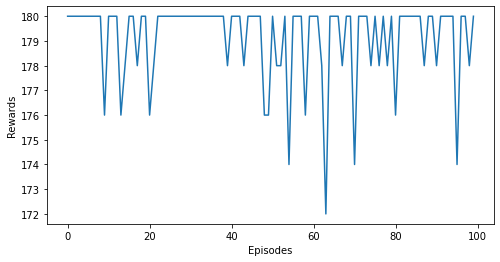

```python
plt.figure(figsize=(8,4))
plt.plot(rewards_test_DQNTemp[0], label='Rewards')
plt.xlabel('Episodes')
plt.ylabel('Rewards')
plt.show()
```

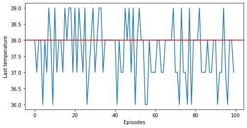

```python
plot_temperature(rewards_test_DQNTemp[1])
```